# Reproducible Research: Peer Assessment 1

Daniel Friedheim

April 26, 2017

# Activity Data Report

### Introduction

It is now possible to collect a large amount of data about personal movement using activity monitoring devices such as a *Fitbit*, *Nike Fuelband*, or *Jawbone Up*. These type of devices are part of the “quantified self” movement – a group of enthusiasts who take measurements about themselves regularly to improve their health, to find patterns in their behavior, or because they are tech geeks. But these data remain under-utilized both because the raw data are hard to obtain and there is a lack of statistical methods and software for processing and interpreting the data.

This report explores data from a personal activity monitoring device. This device collects data at **5 minute intervals** through out the day. The data consists of two months of data from an anonymous individual collected during the months of **October and November, 2012** and include the **number of steps taken** in 5 minute intervals each day.

## Loading and preprocessing the data

### 1. Code for reading in the dataset and/or processing the data

```r
library(readr)
library(dplyr)
library(ggplot2)
library(lubridate)
activity <- read_csv("./data/activity.csv")
```

## What is mean total number of steps taken per day?

First of all, the **grand total** of all steps taken over this 61-day period is 570608, as generated by this code:

```r
sum(activity$steps, na.rm = TRUE)
```

```
## [1] 570608
```

### 2. Histogram of the total number of steps taken **each** day:

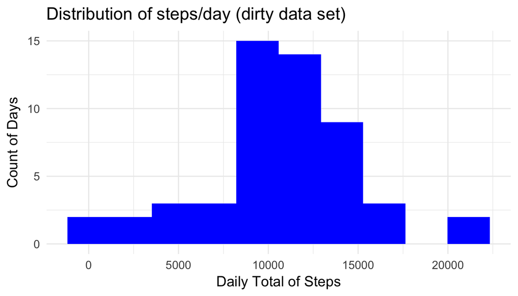

```r
byDate <- group_by(activity, date)
totalByDate <- summarize(byDate, total = sum(steps))
ggplot(totalByDate, aes(total)) + geom_histogram(bins = 10, fill = "blue") +
    labs(title = "Distribution of steps/day (dirty data set)", x = "Daily Total of Steps",
        y = "Count of Days") + theme_minimal(base_size = 14)
```

### 3. Mean and median number of steps taken each day

The **mean** total number of steps taken each day is10766, and the **median** of 10765 is nearly the same, as calculated by this code:

```r
as.integer(round(mean(totalByDate$total, na.rm = TRUE), 0))
```

```
## [1] 10766
```

```r
as.integer(median(totalByDate$total, na.rm = TRUE))
```

```
## [1] 10765
```

## What is the average daily activity pattern?

### 4. Time series plot of the average number of steps taken

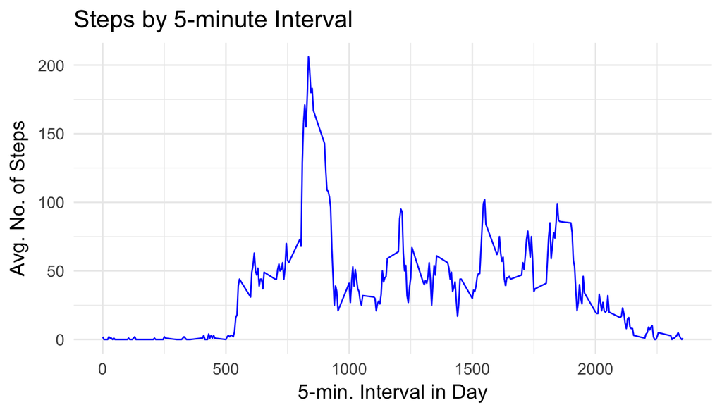

```r
byInterval <- group_by(activity, interval)
meanSteps <- summarize(byInterval, average = round(mean(steps, na.rm = TRUE),
    digits = 0))
ggplot(meanSteps, aes(interval, average)) + geom_line(col = "blue") + theme_minimal(base_size = 14) +
    labs(title = "Steps by 5-minute Interval", x = "5-min. Interval in Day",
        y = "Avg. No. of Steps")
```

### 5. The 5-minute interval that, on average, contains the maximum number of steps

The index number of the 5-minute interval with the **highest** average number of steps across all days, and that average, are 835, 206, respectively, as calculated by this code:

```r
filter(meanSteps, average == max(average))
```

```
## # A tibble: 1 × 2
##   interval average
##      <int>   <dbl>
## 1      835     206
```

## Imputing missing values

The **total** number of rows with the missing value of NA for *steps* is 2304, as calculated by this code:

```r
sum(is.na(activity$steps))
```

```
## [1] 2304
```

### 6. Code to describe and show a strategy for imputing missing data

Since the number of steps varies widely by 5-minute interval, it would be best to impute them by interval, as well. And, since the pattern of NAs is not scattered, but rather concentrated in all 288 intervals/day of just 8 out of 61 days, we may impute a full “set” of average steps by interval for each of those days:

```r
imputedSteps <- meanSteps$average
cleanByInterval <- byInterval
cleanByInterval[cleanByInterval$date == "2012-10-01", ]$steps <- imputedSteps
cleanByInterval[cleanByInterval$date == "2012-10-08", ]$steps <- imputedSteps
cleanByInterval[cleanByInterval$date == "2012-11-01", ]$steps <- imputedSteps
cleanByInterval[cleanByInterval$date == "2012-11-04", ]$steps <- imputedSteps
cleanByInterval[cleanByInterval$date == "2012-11-09", ]$steps <- imputedSteps
cleanByInterval[cleanByInterval$date == "2012-11-10", ]$steps <- imputedSteps
cleanByInterval[cleanByInterval$date == "2012-11-14", ]$steps <- imputedSteps
cleanByInterval[cleanByInterval$date == "2012-11-30", ]$steps <- imputedSteps
```

Just to be safe, let’s confirm that there are no more NAs left and that the clean **new** dataset retains the original 17,568 records of 3 variables:

```r
sum(is.na(cleanByInterval$steps))
```

```
## [1] 0
```

```r
dim(cleanByInterval)
```

```
## [1] 17568     3
```

### 7. Histogram of the total number of steps taken each day after missing values are imputed

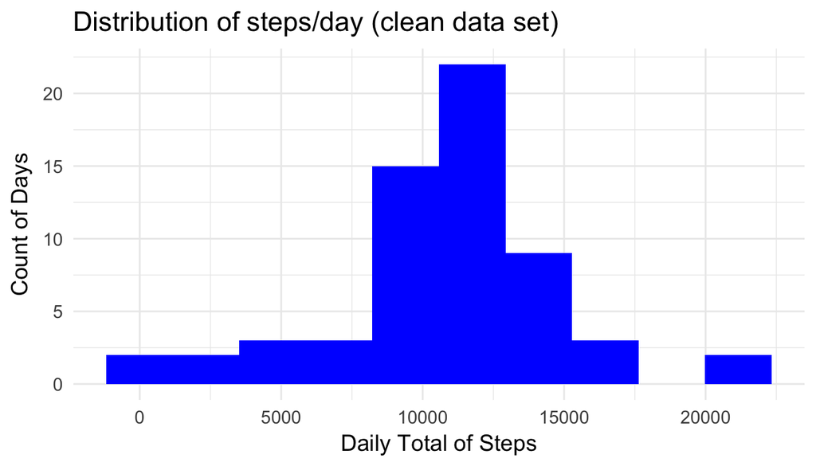

```r
cleanByDate <- group_by(cleanByInterval, date)
totalCleanByDate <- summarize(cleanByDate, total = sum(steps))
ggplot(totalCleanByDate, aes(total)) + geom_histogram(bins = 10, fill = "blue") +
    labs(title = "Distribution of steps/day (clean data set)", x = "Daily Total of Steps",
        y = "Count of Days") + theme_minimal(base_size = 14)
```

For this clean **new** dataset, the **mean** total number of steps taken each day reamains 10766, but the **median** of 10762 diverges a bit more than before imputing, as calculated by this code:

```r
as.integer(round(mean(totalCleanByDate$total, 0)))
```

```
## [1] 10766
```

```r
as.integer(median(totalCleanByDate$total))
```

```
## [1] 10762
```

## Are there differences in activity patterns between weekdays and weekends?

To answer that question, let’s first add a *weekday* variable, then derive from it another *daytype* variable gathering together every *weekday* and every *weekend* day:

```r
cleanByWeekday <- mutate(cleanByDate, weekday = (weekdays(date)))
ungroup(cleanByWeekday)
```

```
## # A tibble: 17,568 × 4
##    steps       date interval weekday
##    <dbl>     <date>    <int>   <chr>
## 1      2 2012-10-01        0  Monday
## 2      0 2012-10-01        5  Monday
## 3      0 2012-10-01       10  Monday
## 4      0 2012-10-01       15  Monday
## 5      0 2012-10-01       20  Monday
## 6      2 2012-10-01       25  Monday
## 7      1 2012-10-01       30  Monday
## 8      1 2012-10-01       35  Monday
## 9      0 2012-10-01       40  Monday
## 10     1 2012-10-01       45  Monday
## # ... with 17,558 more rows
```

```r
cleanByDayType <- mutate(cleanByWeekday, daytype = if_else(weekday %in% c("Saturday",
    "Sunday"), "weekend", "weekday"))
cleanByDayType
```

```
## Source: local data frame [17,568 x 5]
## Groups: date [61]
##
##    steps       date interval weekday daytype
##    <dbl>     <date>    <int>   <chr>   <chr>
## 1      2 2012-10-01        0  Monday weekday
## 2      0 2012-10-01        5  Monday weekday
## 3      0 2012-10-01       10  Monday weekday
## 4      0 2012-10-01       15  Monday weekday
## 5      0 2012-10-01       20  Monday weekday
## 6      2 2012-10-01       25  Monday weekday
## 7      1 2012-10-01       30  Monday weekday
## 8      1 2012-10-01       35  Monday weekday
## 9      0 2012-10-01       40  Monday weekday
## 10     1 2012-10-01       45  Monday weekday
## # ... with 17,558 more rows
```

### 8. Panel plot comparing the average number of steps taken per 5-minute interval across weekdays and weekends

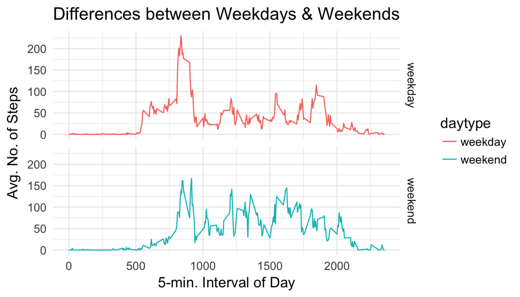

```r
cleanMeanSteps <- summarize(group_by(cleanByDayType, interval, daytype), average = round(mean(steps),
    digits = 0))
ggplot(cleanMeanSteps, aes(interval, average, color = daytype)) + geom_line() +
    theme_minimal(base_size = 14) + facet_grid(daytype ~ .) + labs(title = "Differences between Weekdays & Weekends",
    x = "5-min. Interval of Day", y = "Avg. No. of Steps")
```

## Note:

### 9. All of the R code needed to reproduce the results (numbers, plots, etc.) **are** right in this report.